# IndoAquaStats Visualization

Ian Ladner

June 6, 2018

```r
# Process data into long format
aqua <- aqua %>%
  gather(key = 'year', value = 'value', 4:ncol(.)) %>%
  spread(metric, value) %>%
  mutate(area_hectares = as.numeric(gsub('\\.', '', area_hectares)),
         tons          = as.numeric(gsub('\\.', '', tons)),
         tons_per_ha   = tons / area_hectares,
         NAME_1 = factor(province))
```

Calculate summary statistics to use for maps:

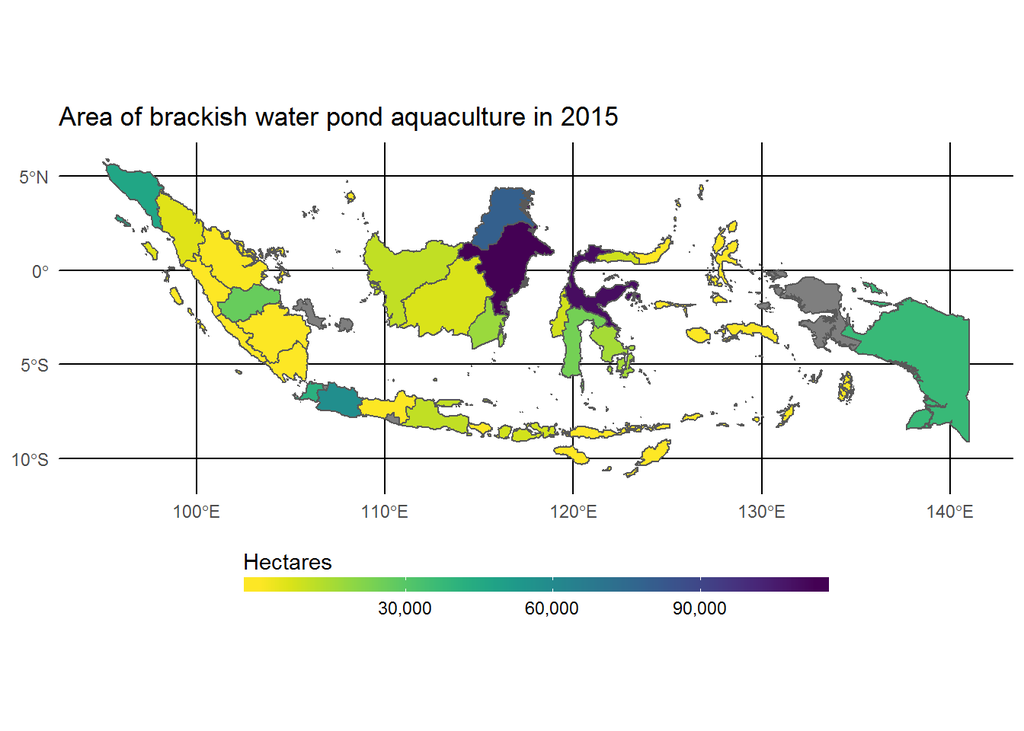

```r
# Area of brackish water ponds
area_map <- aqua %>%
  dplyr::filter(year == 2015 & type == 'brackish pond') %>%
  select(NAME_1, area_hectares)
# Intensity of production
intensity_map <- aqua %>%
  dplyr::filter(year == 2015 & type == 'brackish pond') %>%
  select(NAME_1, tons_per_ha) %>%
  mutate(tons_per_ha = ifelse(tons_per_ha > 1000, NA, tons_per_ha))
# Area of brackish water ponds
prod_map <- aqua %>%
  dplyr::filter(year == 2015 & type == 'brackish pond') %>%
  select(NAME_1, tons)

# Rate of intensity change
perc_change_map <- aqua %>%
  dplyr::filter(type == 'brackish pond') %>%
  group_by(province) %>%
  mutate(perc_change_i  = tons_per_ha / lag(tons_per_ha),
         three_yr_avg_i   = RcppRoll::roll_meanr(perc_change_i, n = 3, na.rm = T),
         perc_change_a  = area_hectares / lag(area_hectares),
         three_yr_avg_a   = RcppRoll::roll_meanr(perc_change_a, n = 3, na.rm = T)) %>%
  mutate(three_yr_avg_i = ifelse(three_yr_avg_i > 200, 200, three_yr_avg_i),
         three_yr_avg_a = ifelse(three_yr_avg_a > 100, 100, three_yr_avg_a)) %>%
  dplyr::filter(year == 2015)

# Join subsets to map data
area_map <- left_join(indo, area_map)
tons_map <- left_join(indo, prod_map)
intensity_map <- left_join(indo, intensity_map)
perc_change_map <- left_join(indo, perc_change_map)
ggplot(area_map) +
  geom_sf(aes(key = NAME_1, fill = area_hectares)) +
  scale_fill_viridis(option = "D", labels = comma, direction = -1) +
  guides(fill = guide_colorbar(barwidth = 20,
                               barheight = 0.5,
                               title = "Hectares",
                               title.position = "top")) +
  labs(title = "Area of brackish water pond aquaculture in 2015") +
  theme_minimal() +
  theme(legend.position = 'bottom')
```

```r
# ggsave(filename = "sfg-aqua-figures/indo_brackish_area.png", width = 8, height = 6)
```

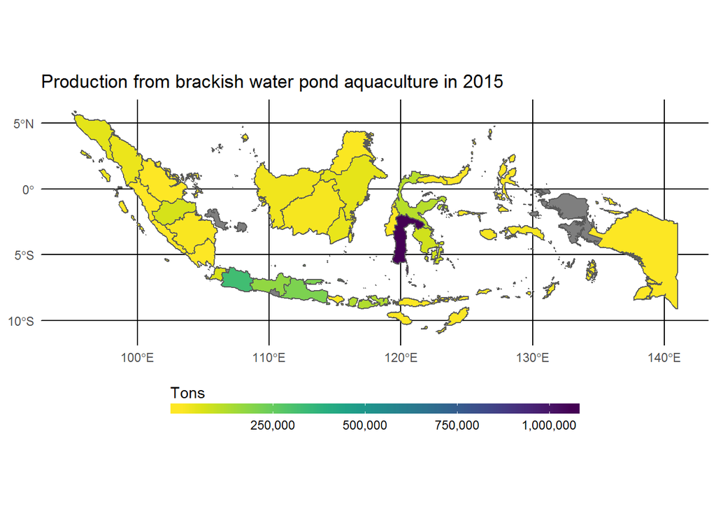

```r
ggplot(tons_map) +
  geom_sf(aes(key = NAME_1, fill = tons)) +
  scale_fill_viridis(option = "D", labels = comma, direction = -1) +
  guides(fill = guide_colorbar(barwidth = 20,
                               barheight = 0.5,
                               title = "Tons",
                               title.position = "top")) +
  labs(title = "Production from brackish water pond aquaculture in 2015") +
  theme_minimal() +
  theme(legend.position = 'bottom')
```

```r
# ggsave(filename = "sfg-aqua-figures/indo_brackish_area.png", width = 8, height = 6)
```

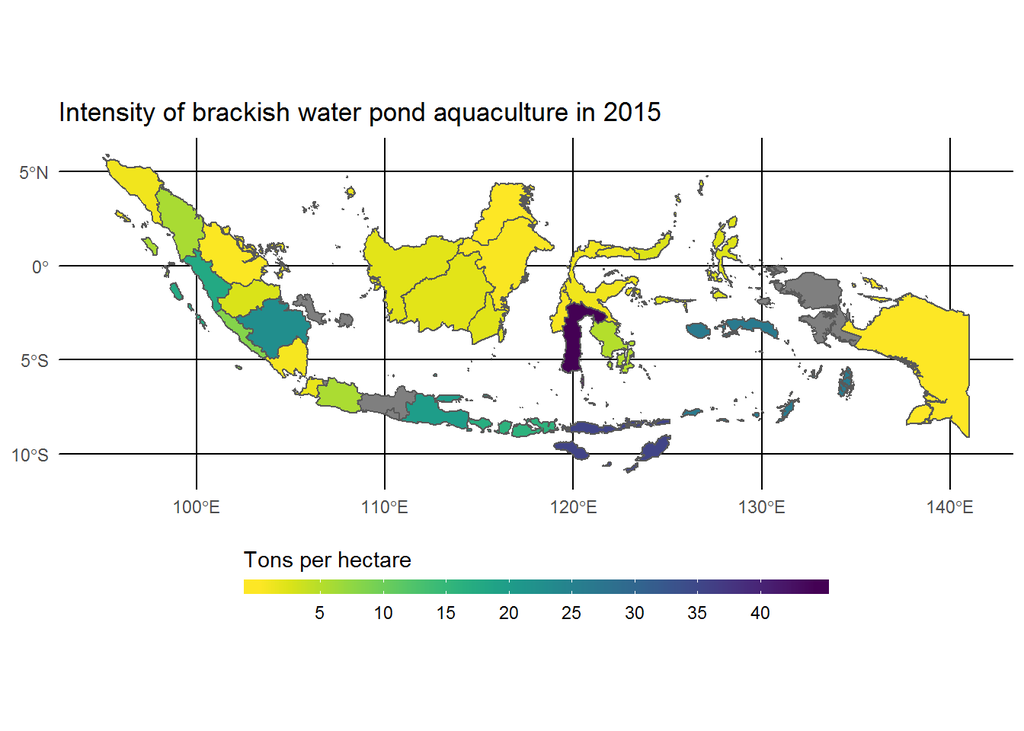

```r
ggplot(intensity_map) +
  geom_sf(aes(fill = tons_per_ha)) +
  scale_fill_viridis(breaks = seq(from = 0, to = 40, by = 5), option = "D", direction = -1) +
  guides(fill = guide_colorbar(barwidth = 20,
                               barheight = 0.5,
                               title = "Tons per hectare",
                               title.position = "top")) +
  labs(title = "Intensity of brackish water pond aquaculture in 2015") +
  theme_minimal() +
  theme(legend.position = 'bottom')
```

```r
# ggsave(filename = "sfg-aqua-figures/indo_brackish_intensity.png", width = 8, height = 6)
```

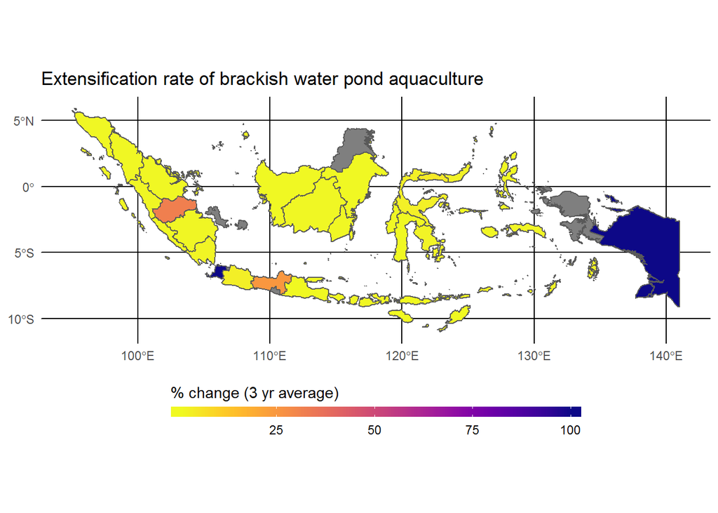

```r
ggplot(perc_change_map) +
  geom_sf(aes(fill = three_yr_avg_a)) +
  scale_fill_viridis(option = "C", direction = -1) +
  guides(fill = guide_colorbar(barwidth = 20,
                               barheight = 0.5,
                               title = "% change (3 yr average)",
                               title.position = "top")) +
  labs(title = "Extensification rate of brackish water pond aquaculture") +
  theme_minimal() +
  theme(legend.position = 'bottom')
```

```r
# ggsave(filename = "sfg-aqua-figures/indo_brackish_perc_change_area.png", width = 8, height = 6)
```

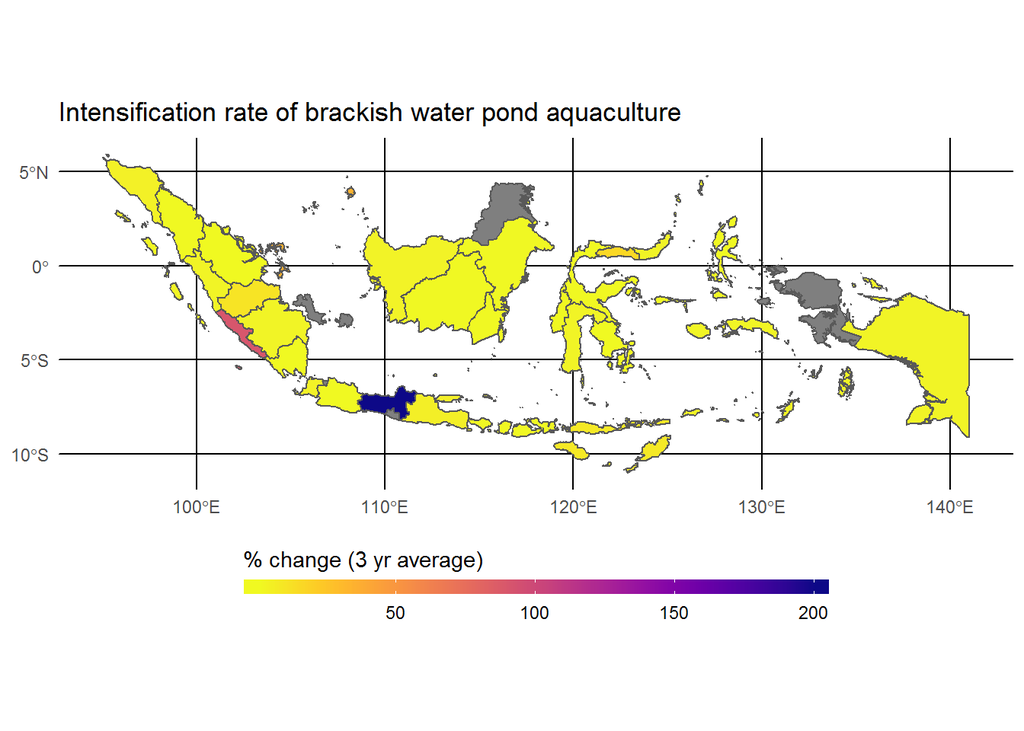

```r
ggplot(perc_change_map) +
  geom_sf(aes(fill = three_yr_avg_i)) +
  scale_fill_viridis(option = "C", direction = -1) +
  guides(fill = guide_colorbar(barwidth = 20,
                               barheight = 0.5,
                               title = "% change (3 yr average)",
                               title.position = "top")) +
  labs(title = "Intensification rate of brackish water pond aquaculture") +
  theme_minimal() +
  theme(legend.position = 'bottom')
```

```r
# ggsave(filename = "sfg-aqua-figures/indo_brackish_perc_change_area.png", width = 8, height = 6)
```

## Production and Area Plots

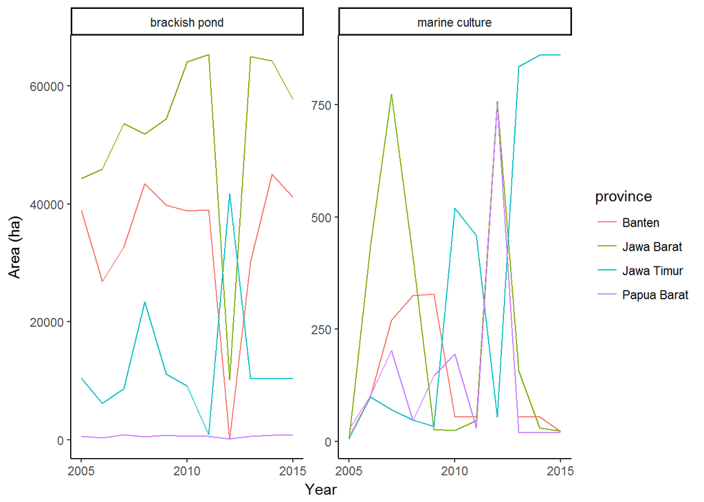

```r
area_plot <- aqua %>%
  filter(province %in% c('Jawa Barat', 'Jawa Timur', 'Banten', 'Papua Barat')) %>%
  filter(type %in% c('brackish pond','marine culture')) %>%
  ggplot(aes(x = as.integer(year), y = area_hectares, color = province)) +
  geom_line()+theme_classic()+labs(x = "Year", y = "Area (ha)")+scale_x_continuous(breaks = c(2005,2010,2015))+facet_wrap(~type, scales = "free")
area_plot
```

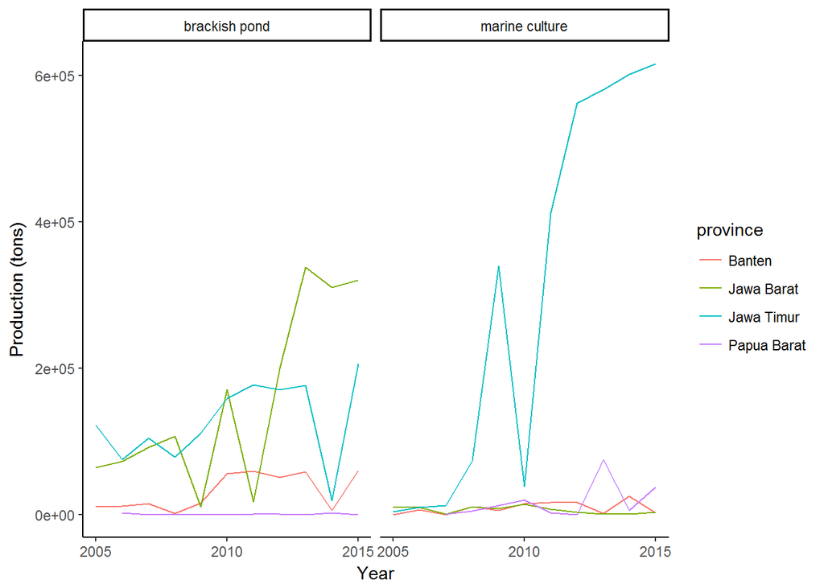

```r
prod_plot <- aqua %>%
  filter(province %in% c('Jawa Barat', 'Jawa Timur', 'Banten', 'Papua Barat')) %>%
  filter(type %in% c('brackish pond','marine culture')) %>%
  ggplot(aes(x = as.integer(year), y = tons, color = province)) +
  geom_line()+theme_classic()+labs(x = "Year", y = "Production (tons)")+scale_x_continuous(breaks = c(2005,2010,2015))+facet_wrap(~type)
prod_plot
```

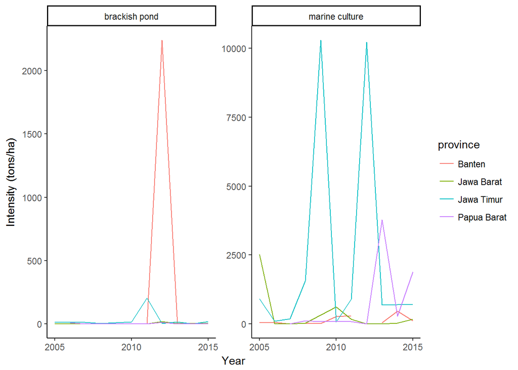

```r
ints_plot <- aqua %>%
  filter(province %in% c('Jawa Barat', 'Jawa Timur', 'Banten', 'Papua Barat')) %>%
  filter(type %in% c('brackish pond','marine culture')) %>%
  ggplot(aes(x = as.integer(year), y = tons_per_ha, color = province)) +
  geom_line()+theme_classic()+labs(x = "Year", y = "Intensity (tons/ha)")+scale_x_continuous(breaks = c(2005,2010,2015))+facet_wrap(~type, scales = "free")
ints_plot
```